# Practical Machine Learning Assignment

### Executive Summary

This analysis aims to classify how well an exercise is performed. Data was collected from accelerometers on the belt, forearm, arm, and dumbell of 6 participants.

From the training data set provided, 48 predictors were selected. As this is a classification problem, *Random Forests* was chosen as the method to fit the model.

### Libraries

```r
library(caret)
library(randomForest)
library(knitr)
library(scales)
```

### Load Data

```r
pml.training <- read.csv("pml-training.csv")
pml.testing <- read.csv("pml-testing.csv")
```

### Exploratory Analysis

A quick inspection of the *pml.training* set reveals a large number of *NA* values. These appear to be the aggregate values and only have values where the row has *new_window == “yes”*. We also examine the variability of each feature to select the predictors for our model.

| Column | NA % | nzv | Column | NA % | nzv |
| --- | --- | --- | --- | --- | --- |
| X | 0.0% | FALSE | amplitude_roll_arm | 97.9% | TRUE |
| user_name | 0.0% | FALSE | amplitude_pitch_arm | 97.9% | TRUE |
| raw_timestamp_part_1 | 0.0% | FALSE | amplitude_yaw_arm | 97.9% | FALSE |
| raw_timestamp_part_2 | 0.0% | FALSE | roll_dumbbell | 0.0% | FALSE |
| cvtd_timestamp | 0.0% | FALSE | pitch_dumbbell | 0.0% | FALSE |
| new_window | 0.0% | TRUE | yaw_dumbbell | 0.0% | FALSE |
| num_window | 0.0% | FALSE | kurtosis_roll_dumbbell | 97.9% | TRUE |
| roll_belt | 0.0% | FALSE | kurtosis_picth_dumbbell | 97.9% | TRUE |
| pitch_belt | 0.0% | FALSE | kurtosis_yaw_dumbbell | 97.9% | TRUE |
| yaw_belt | 0.0% | FALSE | skewness_roll_dumbbell | 97.9% | TRUE |
| total_accel_belt | 0.0% | FALSE | skewness_pitch_dumbbell | 97.9% | TRUE |
| kurtosis_roll_belt | 97.9% | TRUE | skewness_yaw_dumbbell | 97.9% | TRUE |
| kurtosis_picth_belt | 97.9% | TRUE | max_roll_dumbbell | 97.9% | FALSE |
| kurtosis_yaw_belt | 97.9% | TRUE | max_picth_dumbbell | 97.9% | FALSE |
| skewness_roll_belt | 97.9% | TRUE | max_yaw_dumbbell | 97.9% | TRUE |
| skewness_roll_belt.1 | 97.9% | TRUE | min_roll_dumbbell | 97.9% | FALSE |
| skewness_yaw_belt | 97.9% | TRUE | min_pitch_dumbbell | 97.9% | FALSE |
| max_roll_belt | 97.9% | FALSE | min_yaw_dumbbell | 97.9% | TRUE |
| max_picth_belt | 97.9% | FALSE | amplitude_roll_dumbbell | 97.9% | FALSE |
| max_yaw_belt | 97.9% | TRUE | amplitude_pitch_dumbbell | 97.9% | FALSE |
| min_roll_belt | 97.9% | FALSE | amplitude_yaw_dumbbell | 97.9% | TRUE |
| min_pitch_belt | 97.9% | FALSE | total_accel_dumbbell | 0.0% | FALSE |
| min_yaw_belt | 97.9% | TRUE | var_accel_dumbbell | 97.9% | FALSE |
| amplitude_roll_belt | 97.9% | FALSE | avg_roll_dumbbell | 97.9% | FALSE |
| amplitude_pitch_belt | 97.9% | FALSE | stddev_roll_dumbbell | 97.9% | FALSE |
| amplitude_yaw_belt | 97.9% | TRUE | var_roll_dumbbell | 97.9% | FALSE |
| var_total_accel_belt | 97.9% | FALSE | avg_pitch_dumbbell | 97.9% | FALSE |
| avg_roll_belt | 97.9% | FALSE | stddev_pitch_dumbbell | 97.9% | FALSE |
| stddev_roll_belt | 97.9% | FALSE | var_pitch_dumbbell | 97.9% | FALSE |
| var_roll_belt | 97.9% | FALSE | avg_yaw_dumbbell | 97.9% | FALSE |
| avg_pitch_belt | 97.9% | FALSE | stddev_yaw_dumbbell | 97.9% | FALSE |
| stddev_pitch_belt | 97.9% | FALSE | var_yaw_dumbbell | 97.9% | FALSE |
| var_pitch_belt | 97.9% | FALSE | gyros_dumbbell_x | 0.0% | FALSE |
| avg_yaw_belt | 97.9% | FALSE | gyros_dumbbell_y | 0.0% | FALSE |
| stddev_yaw_belt | 97.9% | FALSE | gyros_dumbbell_z | 0.0% | FALSE |
| var_yaw_belt | 97.9% | FALSE | accel_dumbbell_x | 0.0% | FALSE |
| gyros_belt_x | 0.0% | FALSE | accel_dumbbell_y | 0.0% | FALSE |
| gyros_belt_y | 0.0% | FALSE | accel_dumbbell_z | 0.0% | FALSE |
| gyros_belt_z | 0.0% | FALSE | magnet_dumbbell_x | 0.0% | FALSE |
| accel_belt_x | 0.0% | FALSE | magnet_dumbbell_y | 0.0% | FALSE |
| accel_belt_y | 0.0% | FALSE | magnet_dumbbell_z | 0.0% | FALSE |
| accel_belt_z | 0.0% | FALSE | roll_forearm | 0.0% | FALSE |
| magnet_belt_x | 0.0% | FALSE | pitch_forearm | 0.0% | FALSE |
| magnet_belt_y | 0.0% | FALSE | yaw_forearm | 0.0% | FALSE |
| magnet_belt_z | 0.0% | FALSE | kurtosis_roll_forearm | 97.9% | TRUE |
| roll_arm | 0.0% | FALSE | kurtosis_picth_forearm | 97.9% | TRUE |
| pitch_arm | 0.0% | FALSE | kurtosis_yaw_forearm | 97.9% | TRUE |
| yaw_arm | 0.0% | FALSE | skewness_roll_forearm | 97.9% | TRUE |
| total_accel_arm | 0.0% | FALSE | skewness_pitch_forearm | 97.9% | TRUE |
| var_accel_arm | 97.9% | FALSE | skewness_yaw_forearm | 97.9% | TRUE |
| avg_roll_arm | 97.9% | TRUE | max_roll_forearm | 97.9% | TRUE |
| stddev_roll_arm | 97.9% | TRUE | max_picth_forearm | 97.9% | FALSE |
| var_roll_arm | 97.9% | TRUE | max_yaw_forearm | 97.9% | TRUE |
| avg_pitch_arm | 97.9% | TRUE | min_roll_forearm | 97.9% | TRUE |
| stddev_pitch_arm | 97.9% | TRUE | min_pitch_forearm | 97.9% | FALSE |
| var_pitch_arm | 97.9% | TRUE | min_yaw_forearm | 97.9% | TRUE |
| avg_yaw_arm | 97.9% | TRUE | amplitude_roll_forearm | 97.9% | TRUE |
| stddev_yaw_arm | 97.9% | TRUE | amplitude_pitch_forearm | 97.9% | FALSE |
| var_yaw_arm | 97.9% | TRUE | amplitude_yaw_forearm | 97.9% | TRUE |
| gyros_arm_x | 0.0% | FALSE | total_accel_forearm | 0.0% | FALSE |
| gyros_arm_y | 0.0% | FALSE | var_accel_forearm | 97.9% | FALSE |
| gyros_arm_z | 0.0% | FALSE | avg_roll_forearm | 97.9% | TRUE |
| accel_arm_x | 0.0% | FALSE | stddev_roll_forearm | 97.9% | TRUE |
| accel_arm_y | 0.0% | FALSE | var_roll_forearm | 97.9% | TRUE |
| accel_arm_z | 0.0% | FALSE | avg_pitch_forearm | 97.9% | TRUE |
| magnet_arm_x | 0.0% | FALSE | stddev_pitch_forearm | 97.9% | TRUE |
| magnet_arm_y | 0.0% | FALSE | var_pitch_forearm | 97.9% | TRUE |
| magnet_arm_z | 0.0% | FALSE | avg_yaw_forearm | 97.9% | TRUE |
| kurtosis_roll_arm | 97.9% | TRUE | stddev_yaw_forearm | 97.9% | TRUE |
| kurtosis_picth_arm | 97.9% | TRUE | var_yaw_forearm | 97.9% | TRUE |
| kurtosis_yaw_arm | 97.9% | TRUE | gyros_forearm_x | 0.0% | FALSE |
| skewness_roll_arm | 97.9% | TRUE | gyros_forearm_y | 0.0% | FALSE |
| skewness_pitch_arm | 97.9% | TRUE | gyros_forearm_z | 0.0% | FALSE |
| skewness_yaw_arm | 97.9% | TRUE | accel_forearm_x | 0.0% | FALSE |
| max_roll_arm | 97.9% | TRUE | accel_forearm_y | 0.0% | FALSE |
| max_picth_arm | 97.9% | FALSE | accel_forearm_z | 0.0% | FALSE |
| max_yaw_arm | 97.9% | FALSE | magnet_forearm_x | 0.0% | FALSE |
| min_roll_arm | 97.9% | TRUE | magnet_forearm_y | 0.0% | FALSE |
| min_pitch_arm | 97.9% | TRUE | magnet_forearm_z | 0.0% | FALSE |
| min_yaw_arm | 97.9% | FALSE | amplitude_roll_arm | 97.9% | TRUE |

We settle on 48 raw measures which have no *NA* values, and exclude the row number (X), user name, timestamps and totals.

| Column | Column | Column | Column | Column | Column | Column |
| --- | --- | --- | --- | --- | --- | --- |
| roll_belt | accel_belt_y | yaw_arm | magnet_arm_x | gyros_dumbbell_y | magnet_dumbbell_z | accel_forearm_x |
| pitch_belt | accel_belt_z | gyros_arm_x | magnet_arm_y | gyros_dumbbell_z | roll_forearm | accel_forearm_y |
| yaw_belt | magnet_belt_x | gyros_arm_y | magnet_arm_z | accel_dumbbell_x | pitch_forearm | accel_forearm_z |
| gyros_belt_x | magnet_belt_y | gyros_arm_z | roll_dumbbell | accel_dumbbell_y | yaw_forearm | magnet_forearm_x |
| gyros_belt_y | magnet_belt_z | accel_arm_x | pitch_dumbbell | accel_dumbbell_z | gyros_forearm_x | magnet_forearm_y |
| gyros_belt_z | roll_arm | accel_arm_y | yaw_dumbbell | magnet_dumbbell_x | gyros_forearm_y | magnet_forearm_z |
| accel_belt_x | pitch_arm | accel_arm_z | gyros_dumbbell_x | magnet_dumbbell_y | gyros_forearm_z | classe |

### Partition the Data

To cross validate our results, we partition the training set, building our model on 75% of the initial data.

As we have decided to exclude the aggregate data, we will only use rows where *new_window == “no”*.

```r
intrain <- createDataPartition(
  y=pml.training[pml.training$new_window == "no", "classe"],
  p = 0.75,
  list = FALSE
)
training <- pml.training[pml.training$new_window == "no", ][intrain, cols]
testing <- pml.training[pml.training$new_window == "no", ][-intrain, cols]
```

### Training the Model

As this is a classification problem, *Random Forests* is chosen as the algorithm.

```r
model.training.rf <- randomForest(classe ~ ., data = training)

model.training.rf
```

```
##
## Call:
##  randomForest(formula = classe ~ ., data = training)
##                Type of random forest: classification
##                      Number of trees: 500
## No. of variables tried at each split: 6
##
##         OOB estimate of  error rate: 0.5%
## Confusion matrix:
##      A    B    C    D    E class.error
## A 4097    6    0    0    1 0.001705653
## B   10 2777    2    0    0 0.004302617
## C    0   17 2493    4    0 0.008353222
## D    0    0   24 2335    2 0.011012283
## E    0    0    2    4 2640 0.002267574
```

We can see that the out of bag error on the training set is 0.5%.

Next, we plot the variable importance measured by the model.

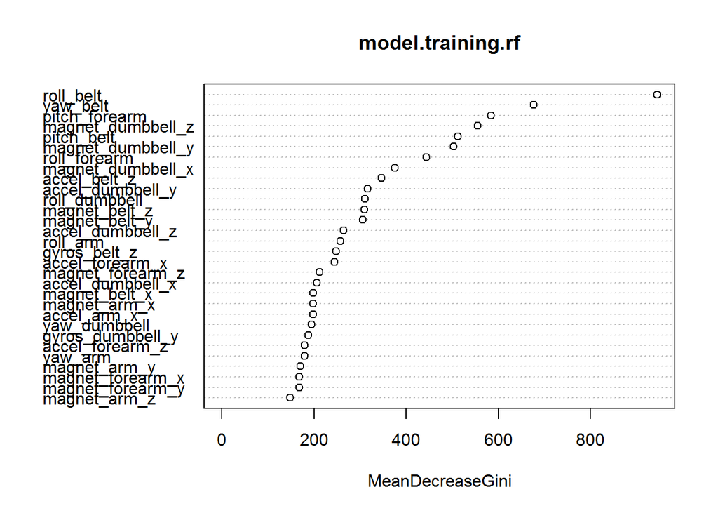

### Testing the Model

We now cross validate our model on the remaining 25% of the original training data.

```r
predict.testing <- predict(model.training.rf, testing)
```

Testing confusion matrix.

```
##
## predict.testing    A    B    C    D    E
##               A 1365    4    0    0    0
##               B    1  920    4    0    0
##               C    0    5  831    5    1
##               D    0    0    3  781    3
##               E    1    0    0    0  878
```

The estimate for the out of sample error is 0.562%.

### Predict Submission Results

Finally, we predict the class for the 20 samples in the *pml-testing.csv* file.

```r
predict.submission <- predict(model.training.rf, pml.testing)
```